# Final Project ITMS-514

Group 13

Due Date 11/26

# California Avocado Production 1980-2020

## About Dataset

Parts of California has the right weather conditions to produce a lot of avocados. This data consist of 40 years of California Avocado production by county per year.

In this dataset you will find the annual amount of acres harvested, yield, production, price per unit, total value by county.

This data could be used to practice data visualization, data cleaning, forecasting

The data is from USDA’s National Agricultural Statistics Service California Field Office (Part of the Pacific Regional Field Office).

## Data Preperation

**Observations of the Dataset**

```r
str(avocado_data)
```

```
## 'data.frame':    420 obs. of  11 variables:
##  $ Year           : num  2020 2020 2020 2020 2020 ...
##  $ Commodity.Code : num  221999 221999 221999 221999 221999 ...
##  $ Crop.Name      : chr  "AVOCADOS ALL " "AVOCADOS ALL " "AVOCADOS ALL " "AVOCADOS ALL " ...
##  $ County.Code    : num  53 65 71 73 79 83 111 53 65 71 ...
##  $ County         : chr  "Monterey " "Riverside " "San Bernardino " "San Diego " ...
##  $ Harvested.Acres: num  223 3020 370 14400 4240 5770 16400 225 2940 397 ...
##  $ Yield          : num  5.56 NA 2.16 3.51 5.9 4.89 4.29 6.58 5.48 3.53 ...
##  $ Production     : num  1240 NA 799 50500 25000 28200 70300 1480 16100 1400 ...
##  $ Price.P.U      : num  2380 NA 2617 3029 1887 ...
##  $ Unit           : chr  "Tons " "Tons " "Tons " "Tons " ...
##  $ Value          : int  2951000 88697000 2091000 152958000 47169000 80161000 179727000 3700000 40339000 3646000 ...
```

```r
summary(avocado_data)
```

```
##       Year      Commodity.Code    Crop.Name          County.Code
##  Min.   :1980   Min.   :221999   Length:420         Min.   :  7.0
##  1st Qu.:1988   1st Qu.:221999   Class :character   1st Qu.: 59.0
##  Median :1997   Median :221999   Mode  :character   Median : 73.0
##  Mean   :1998   Mean   :221999                      Mean   :120.3
##  3rd Qu.:2008   3rd Qu.:221999                      3rd Qu.: 83.0
##  Max.   :2020   Max.   :221999                      Max.   :991.0
##
##     County          Harvested.Acres       Yield         Production
##  Length:420         Min.   :    4.0   Min.   :0.140   Min.   :    29.0
##  Class :character   1st Qu.:  227.5   1st Qu.:1.870   1st Qu.:   826.5
##  Mode  :character   Median : 1581.5   Median :2.900   Median :  5243.5
##                     Mean   : 6344.1   Mean   :2.938   Mean   : 19203.4
##                     3rd Qu.: 8375.2   3rd Qu.:3.850   3rd Qu.: 26340.0
##                     Max.   :36800.0   Max.   :8.600   Max.   :160574.0
##                     NA's   :18        NA's   :26      NA's   :26
##    Price.P.U          Unit               Value
##  Min.   : 163.0   Length:420         Min.   :     9000
##  1st Qu.: 877.8   Class :character   1st Qu.:   988900
##  Median :1618.0   Mode  :character   Median :  8166750
##  Mean   :1576.2                      Mean   : 30823364
##  3rd Qu.:2112.3                      3rd Qu.: 41096800
##  Max.   :3958.1                      Max.   :251452100
##  NA's   :26                          NA's   :18
```

## Missing values

**TOTAL**

```r
which(is.na(avocado_data))
```

```
##   [1] 2361 2371 2378 2379 2405 2406 2411 2417 2420 2421 2426 2432 2435 2437 2439
##  [16] 2442 2447 2449 2522 2535 2726 2737 2768 2779 2781 2791 2798 2799 2812 2824
##  [31] 2825 2826 2831 2837 2840 2841 2846 2852 2855 2857 2859 2862 2867 2869 2942
##  [46] 2955 3146 3157 3188 3199 3201 3211 3218 3219 3232 3244 3245 3246 3251 3257
##  [61] 3260 3261 3266 3272 3275 3277 3279 3282 3287 3289 3362 3375 3566 3577 3608
##  [76] 3619 3621 3631 3638 3639 3652 3664 3665 3666 3671 3677 3680 3681 3686 3692
##  [91] 3695 3697 3699 3702 3707 3709 4461 4471 4478 4479 4505 4506 4511 4517 4520
## [106] 4521 4526 4532 4535 4537 4539 4542 4547 4549
```

```r
sum(is.na(avocado_data))
```

```
## [1] 114
```

## Histogram

**Harvested Acres**

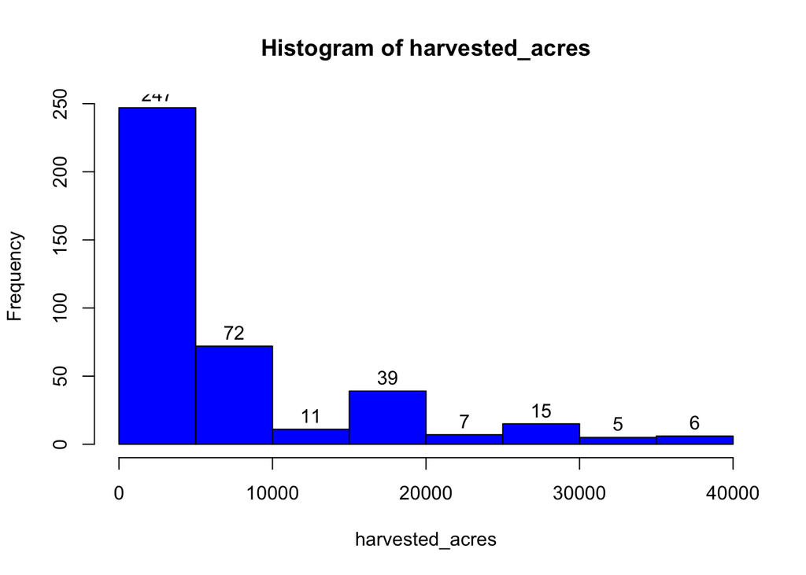

```r
harvested_acres <- avocado_data$Harvested.Acres
h1 <- hist(harvested_acres, col = "blue")
text(h1$mids, h1$counts, labels = h1$counts, adj = c(0.5, -0.5))
```

**Yield**

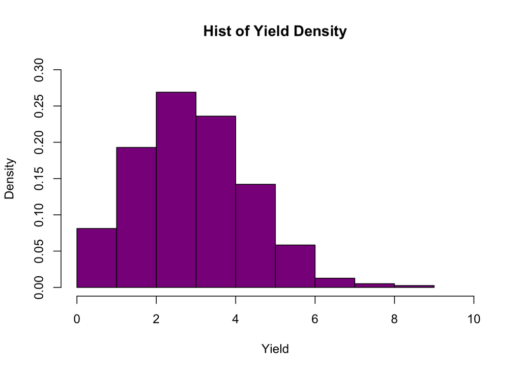

```r
hist(avocado_data$Yield, ylim = c(0, .3), main = "Hist of Yield Density",
xlab = "Yield", xlim = c(0, 10),
col = "darkmagenta", freq = FALSE)
```

## Overlay Histogram

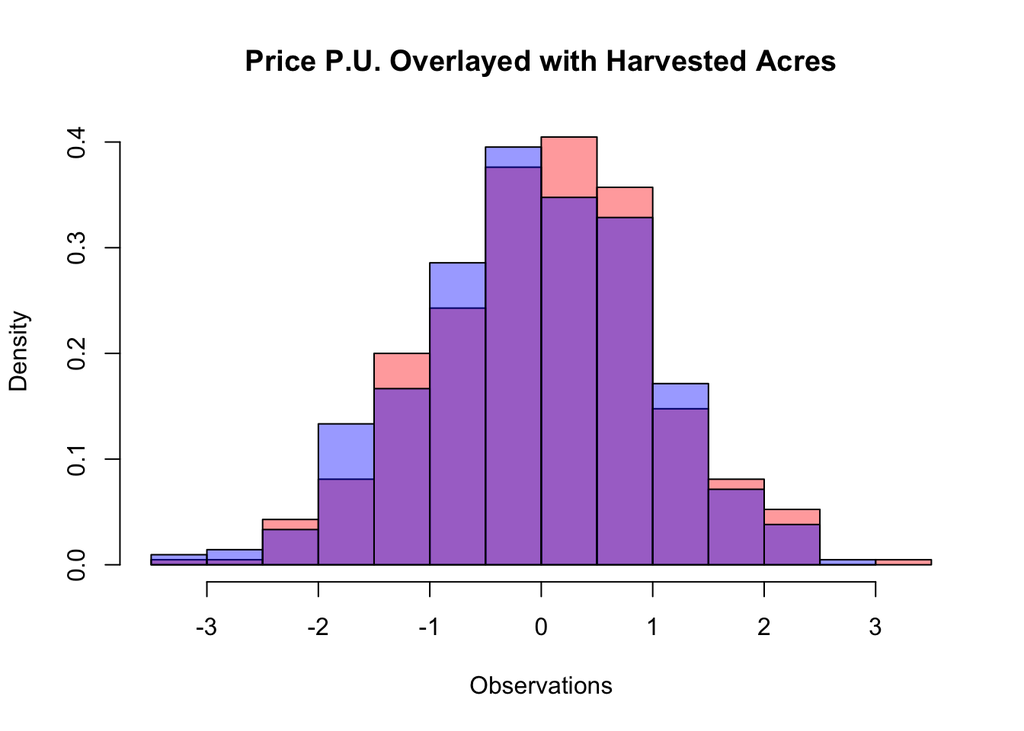

```r
data_1 <- (rnorm(avocado_data$Harvested.Acres))
data_2 <- (rnorm(avocado_data$Price.P.U))
Histogram_1 <- hist( data_1, plot = FALSE)
Histogram_2 <- hist( data_2, plot = FALSE)
plot (Histogram_1, col = rgb(1,0,0,0.4),xlab = 'Observations',freq = FALSE, main = "Price P.U. Overlayed with Harvested Acres")
plot (Histogram_2, xaxt = Year, yaxt = Harvested.Acres,col = rgb(0,0,1,0.4), add = TRUE, freq = FALSE)
```

## Boxplot

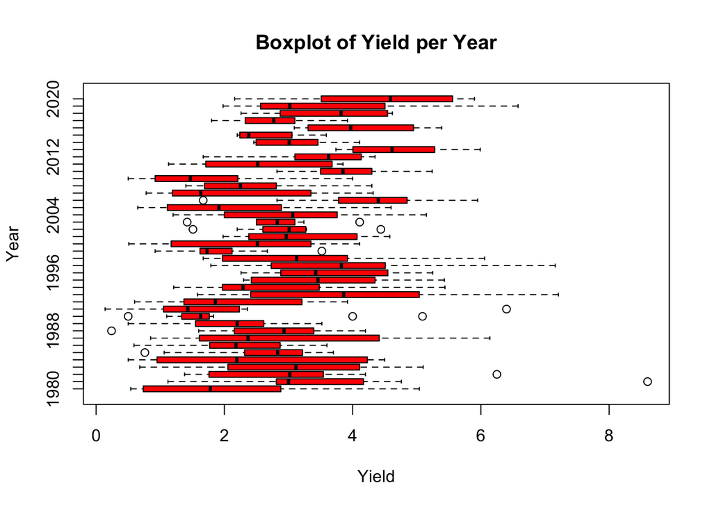

```r
boxplot(Yield ~ Year, data = avocado_data, col = "red",
main = "Boxplot of Yield per Year", xlab = "Yield", ylab =
"Year", horizontal = TRUE)
```

## Hypothesis Test

> H0: μ = 1488.728 Ha: μ ≠ 1488.728 H0: μ = 1726.285 Ha: μ ≠ 1726.285 Null Hypothesis: The amount of acres being harvested does not affect the price per unit of avocados **Price mean**

```r
price_mean <- mean(avocado_data$Price.P.U, na.rm = TRUE)
print(price_mean)
```

```
## [1] 1576.154
```

**Subset of Smaller Harvests** > Small Harvests

```r
harvest_mean <- mean(avocado_data$Harvested.Acres, na.rm = TRUE)
small_harvest <- subset.data.frame(avocado_data, avocado_data$Harvested.Acres < harvest_mean)
small_harvest_price_mean <- mean(small_harvest$Price.P.U, na.rm = TRUE)
print(small_harvest_price_mean)
```

```
## [1] 1488.728
```

**Subset of Larger Harvests** > Large Harvests

```r
large_harvest <- subset.data.frame(avocado_data, avocado_data$Harvested.Acres > harvest_mean)
large_harvest_price_mean <- mean(large_harvest$Price.P.U, na.rm = TRUE)
print(large_harvest_price_mean)
```

```
## [1] 1726.285
```

**t-test**

```r
t.test(x = avocado_data$Price.P.U, mu = small_harvest_price_mean)
```

```
##
##  One Sample t-test
##
## data:  avocado_data$Price.P.U
## t = 2.2678, df = 393, p-value = 0.02388
## alternative hypothesis: true mean is not equal to 1488.728
## 95 percent confidence interval:
##  1500.363 1651.944
## sample estimates:
## mean of x
##  1576.154
```

```r
t.test(x = avocado_data$Price.P.U, mu = large_harvest_price_mean)
```

```
##
##  One Sample t-test
##
## data:  avocado_data$Price.P.U
## t = -3.8944, df = 393, p-value = 0.0001156
## alternative hypothesis: true mean is not equal to 1726.285
## 95 percent confidence interval:
##  1500.363 1651.944
## sample estimates:
## mean of x
##  1576.154
```

> Conclusion: Null hypothesis is rejected and the alternative is true because the mean price per unit for the subsets of small harvests or large harvests does not reflect the price per unit of the total population.

## Linear Regression Model

**Linear Regression Model**

```r
acres_production_regression <- lm(Production ~ Harvested.Acres,
  data = avocado_data)
summary(acres_production_regression)
```

```
##
## Call:
## lm(formula = Production ~ Harvested.Acres, data = avocado_data)
##
## Residuals:
##    Min     1Q Median     3Q    Max
## -45922  -1680    191   1379  53299
##
## Coefficients:
##                   Estimate Std. Error t value Pr(>|t|)
## (Intercept)     -271.83724  680.87143  -0.399     0.69
## Harvested.Acres    3.01394    0.06304  47.813   <2e-16 ***
## ---
## Signif. codes:  0 '***' 0.001 '**' 0.01 '*' 0.05 '.' 0.1 ' ' 1
##
## Residual standard error: 10830 on 392 degrees of freedom
##   (26 observations deleted due to missingness)
## Multiple R-squared:  0.8536, Adjusted R-squared:  0.8533
## F-statistic:  2286 on 1 and 392 DF,  p-value: < 2.2e-16
```

**Linear Regression Plotted**

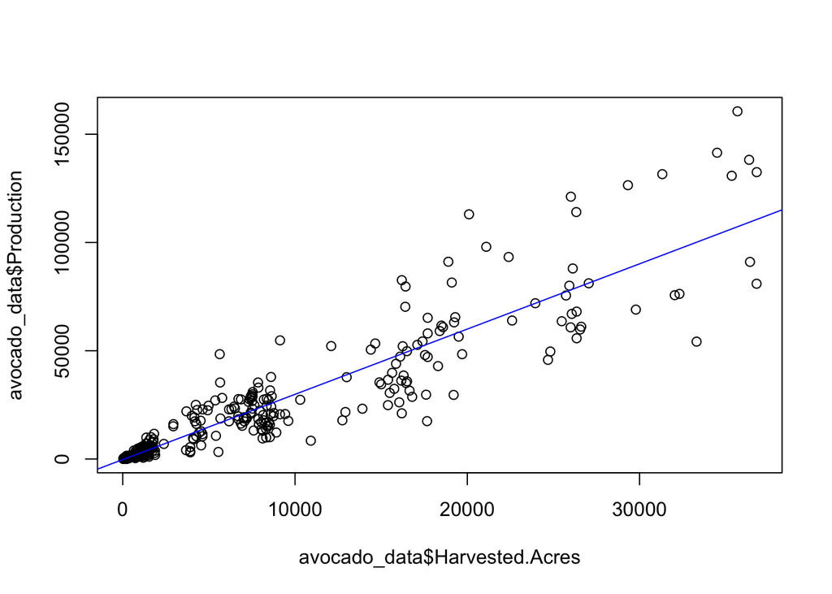

```r
plot(avocado_data$Harvested.Acres, avocado_data$Production)
abline(acres_production_regression, col = "blue")
```